# Single-cell RNA-seq

Roberto Álvarez

4/26/2021

# 1 La estructura de los datos

Después de instalar hay que cargar las librerías para esta sesión

```r
library(SingleCellExperiment)
```

## 1.1 Cargar los datos experimentales

En esta parte simularemos tablas de cuentas de genes por célula

```r
counts_matrix <- data.frame(cell_1 = rpois(10, 10),
                    cell_2 = rpois(10, 10),
                    cell_3 = rpois(10, 30))
rownames(counts_matrix) <- paste0("gene_", 1:10)
counts_matrix <- as.matrix(counts_matrix) # must be a matrix object!
```

1. Checar que se trate de un objeto tipo matriz
2. ¿De qué dimesnión es?
3. ¿Qué significan los renglones y que las columnas?
4. ¿Qué hace la función `rpois()`?

Para convertir esta matriz en un objeto de tipo *single cell experiment* usamos la función del paquete que acabamos de cargar `SingleCellExperiment()`

```r
sce <- SingleCellExperiment(assays = list(counts = counts_matrix))
```

Para visualizar la estructura de ese objeto podemos teclear el nombre que le asignamos o utilizar la función `str()`. Esta última función es más poderosa porque arroja más información pero , a menudo, es demasiada información para que uno pueda procesarla.

```r
sce
```

```
## class: SingleCellExperiment
## dim: 10 3
## metadata(0):
## assays(1): counts
## rownames(10): gene_1 gene_2 ... gene_9 gene_10
## rowData names(0):
## colnames(3): cell_1 cell_2 cell_3
## colData names(0):
## reducedDimNames(0):
## altExpNames(0):
```

```r
str(sce)
```

[output not shown]

[output cut: 53 more lines]

```
##   .. .. .. .. .. .. ..- attr(*, "dimnames")=List of 2
##   .. .. .. .. .. .. .. ..$ : chr [1:10] "gene_1" "gene_2" "gene_3" "gene_4" ...
##   .. .. .. .. .. .. .. ..$ : chr [1:3] "cell_1" "cell_2" "cell_3"
##   .. .. .. .. ..@ elementType    : chr "ANY"
##   .. .. .. .. ..@ elementMetadata: NULL
##   .. .. .. .. ..@ metadata       : list()
##   ..@ NAMES              : NULL
##   ..@ elementMetadata    :Formal class 'DFrame' [package "S4Vectors"] with 6 slots
##   .. .. ..@ rownames       : NULL
##   .. .. ..@ nrows          : int 10
##   .. .. ..@ listData       : Named list()
##   .. .. ..@ elementType    : chr "ANY"
##   .. .. ..@ elementMetadata: NULL
##   .. .. ..@ metadata       : list()
##   ..@ metadata           : list()
```

Para acceder a las cuentas de los datos podemos utilizar dos funciones: `assay(sce,c"counts")` o simplemente `counts(sce)`

```r
counts(sce)
```

```
##         cell_1 cell_2 cell_3
## gene_1       9     10     28
## gene_2      11      6     28
## gene_3      15     15     34
## gene_4       8      9     30
## gene_5       9     12     29
## gene_6      12      3     22
## gene_7       8      9     28
## gene_8      12     11     29
## gene_9       8      9     32
## gene_10      8      9     25
```

1. Utiliza la función `assay(sce,c"counts")` y describe lo qué sale y las diferencias con la función `counts()`

## 1.2 Agregar más `assays`

Esto puede ser útil, por ejemplo en una situación en donde podemos tener en un sólo objeto la versión cruda de los datos y la versión normalizada en el mismo, de tal forma que así no perdemos información.

```r
sce <- scater::logNormCounts(sce)
```

Ahora vemos lo que sucede con el objeto

```r
sce
```

```
## class: SingleCellExperiment
## dim: 10 3
## metadata(0):
## assays(2): counts logcounts
## rownames(10): gene_1 gene_2 ... gene_9 gene_10
## rowData names(0):
## colnames(3): cell_1 cell_2 cell_3
## colData names(1): sizeFactor
## reducedDimNames(0):
## altExpNames(0):
```

1. Compara qué sale en la parte de `assays` con respecto al objeto original

Si quisieramos acceder a estas últimas cuentas podemos usar la función `logcounts()`

```r
logcounts(sce)
```

```
##           cell_1   cell_2   cell_3
## gene_1  3.939227 4.180515 4.057780
## gene_2  4.211531 3.495640 4.057780
## gene_3  4.638074 4.738710 4.322519
## gene_4  3.781010 4.037326 4.151528
## gene_5  3.939227 4.430228 4.105415
## gene_6  4.330558 2.618188 3.733291
## gene_7  3.781010 4.037326 4.057780
## gene_8  4.330558 4.310767 4.105415
## gene_9  3.781010 4.037326 4.239555
## gene_10 3.781010 4.037326 3.904639
```

Podemos ver específicamente cuántos `assays` tiene el objeto `sce`

```r
assays(sce)
```

```
## List of length 2
## names(2): counts logcounts
```

Podemos hacer esta operación manual, es decir que no lo ha automático

```r
counts_100 <- counts(sce) + 100
assay(sce, "counts_100") <- counts_100 # assign a new entry to assays slot
assays(sce) # new assay has now been added.
```

```
## List of length 3
## names(3): counts logcounts counts_100
```

## 1.3 Metadatos

Todas las bases tienen metadatos. Los metadatos son toda aquella información adicional que nos permite interpretar los datos, por ejmplo, si la muestra viene de cierto tipo de pacientes: edad, género, condicón física, etc.

### 1.3.1 Pro columnas

```r
cell_metadata <- data.frame(batch = c(1, 1, 2))
rownames(cell_metadata) <- paste0("cell_", 1:3)
```

```r
sce <- SingleCellExperiment(assays = list(counts = counts_matrix),
    colData = cell_metadata)
```

```r
sce
```

```
## class: SingleCellExperiment
## dim: 10 3
## metadata(0):
## assays(1): counts
## rownames(10): gene_1 gene_2 ... gene_9 gene_10
## rowData names(0):
## colnames(3): cell_1 cell_2 cell_3
## colData names(1): batch
## reducedDimNames(0):
## altExpNames(0):
```

```r
colData(sce)
```

```
## DataFrame with 3 rows and 1 column
##            batch
##        <numeric>
## cell_1         1
## cell_2         1
## cell_3         2
```

```r
sce$batch
```

```
## [1] 1 1 2
```

```r
sce <- SingleCellExperiment(assays = list(counts = counts_matrix),
    colData = cell_metadata)
```

```r
sce <- SingleCellExperiment(assays = list(counts = counts_matrix),
    colData = cell_metadata)
```

```r
sce[,sce$batch==1]
```

```
## class: SingleCellExperiment
## dim: 10 2
## metadata(0):
## assays(1): counts
## rownames(10): gene_1 gene_2 ... gene_9 gene_10
## rowData names(0):
## colnames(2): cell_1 cell_2
## colData names(1): batch
## reducedDimNames(0):
## altExpNames(0):
```

### 1.3.2 Por renglones

```r
rowRanges(sce)
```

```
## GRangesList object of length 10:
## $gene_1
## GRanges object with 0 ranges and 0 metadata columns:
##    seqnames    ranges strand
##       <Rle> <IRanges>  <Rle>
##   -------
##   seqinfo: no sequences
##
## $gene_2
## GRanges object with 0 ranges and 0 metadata columns:
##    seqnames    ranges strand
##       <Rle> <IRanges>  <Rle>
##   -------
##   seqinfo: no sequences
##
## $gene_3
## GRanges object with 0 ranges and 0 metadata columns:
##    seqnames    ranges strand
##       <Rle> <IRanges>  <Rle>
##   -------
##   seqinfo: no sequences
##
## ...
## <7 more elements>
```

```r
sce <- scater::addPerFeatureQC(sce)
rowData(sce)
```

```
## DataFrame with 10 rows and 2 columns
##              mean  detected
##         <numeric> <numeric>
## gene_1    15.6667       100
## gene_2    15.0000       100
## gene_3    21.3333       100
## gene_4    15.6667       100
## gene_5    16.6667       100
## gene_6    12.3333       100
## gene_7    15.0000       100
## gene_8    17.3333       100
## gene_9    16.3333       100
## gene_10   14.0000       100
```

```r
library(AnnotationHub)
#### OJO con esto va atardar un rato

#edb <- AnnotationHub()[["AH73881"]] # Human, Ensembl v97.
#genes(edb)[,2]
```

```r
sce[c("gene_1", "gene_4"), ]
```

```
## class: SingleCellExperiment
## dim: 2 3
## metadata(0):
## assays(1): counts
## rownames(2): gene_1 gene_4
## rowData names(2): mean detected
## colnames(3): cell_1 cell_2 cell_3
## colData names(1): batch
## reducedDimNames(0):
## altExpNames(0):
```

```r
sce[c(1, 4), ] # same as above in this case
```

```
## class: SingleCellExperiment
## dim: 2 3
## metadata(0):
## assays(1): counts
## rownames(2): gene_1 gene_4
## rowData names(2): mean detected
## colnames(3): cell_1 cell_2 cell_3
## colData names(1): batch
## reducedDimNames(0):
## altExpNames(0):
```

### 1.3.3 Otro tipo de metadatos

```r
my_genes <- c("gene_1", "gene_5")
metadata(sce) <- list(favorite_genes = my_genes)
metadata(sce)
```

```
## $favorite_genes
## [1] "gene_1" "gene_5"
```

```r
your_genes <- c("gene_4", "gene_8")
metadata(sce)$your_genes <- your_genes
metadata(sce)
```

```
## $favorite_genes
## [1] "gene_1" "gene_5"
##
## $your_genes
## [1] "gene_4" "gene_8"
```

## 1.4 Campos específicos del objeto single-cell

### 1.4.1 Reducción de la dimesnionalidad

```r
sce <- scater::logNormCounts(sce)
sce <- scater::runPCA(sce)
reducedDim(sce, "PCA")
```

```
##               PC1        PC2
## cell_1 -0.9082840 -0.2720173
## cell_2  1.0925788 -0.1542342
## cell_3 -0.1842948  0.4262515
## attr(,"percentVar")
## [1] 88.01653 11.98347
## attr(,"rotation")
##                  PC1         PC2
## gene_6  -0.857821164  0.03406381
## gene_2  -0.367244100  0.16058129
## gene_5   0.246424903 -0.01750063
## gene_9   0.095259929  0.55792009
## gene_3   0.081897057 -0.53682461
## gene_4   0.103163229  0.42366130
## gene_7   0.111580268  0.28067526
## gene_10  0.125329668  0.04710475
## gene_8   0.009679854 -0.33246671
## gene_1   0.117786985  0.04765575
```

```r
sce <- scater::runTSNE(sce, perplexity = 0.1)
```

```
## Perplexity should be lower than K!
```

```r
reducedDim(sce, "TSNE")
```

```
##              [,1]      [,2]
## cell_1 -4430.6274 -3578.810
## cell_2  5314.6299 -2047.374
## cell_3  -884.0024  5626.184
```

```r
reducedDims(sce)
```

```
## List of length 2
## names(2): PCA TSNE
```

```r
u <- uwot::umap(t(logcounts(sce)), n_neighbors = 2)
reducedDim(sce, "UMAP_uwot") <- u
reducedDims(sce) # Now stored in the object.
```

```
## List of length 3
## names(3): PCA TSNE UMAP_uwot
```

```r
reducedDim(sce, "UMAP_uwot")
```

```
##               [,1]       [,2]
## cell_1  0.64275543  0.1117698
## cell_2 -0.60370835  0.2932522
## cell_3 -0.03904708 -0.4050220
## attr(,"scaled:center")
## [1] -3.527883 -1.517692
```

# 2 Para lxs impacientes: scRNAseq en un sólo paso

```r
library(scRNAseq)
sce <- MacoskoRetinaData()
```

```
## snapshotDate(): 2020-04-27
```

```
## see ?scRNAseq and browseVignettes('scRNAseq') for documentation
```

```
## loading from cache
```

```
## see ?scRNAseq and browseVignettes('scRNAseq') for documentation
```

```
## loading from cache
```

```r
# Objeto pesado

# Quality control.
library(scater)
```

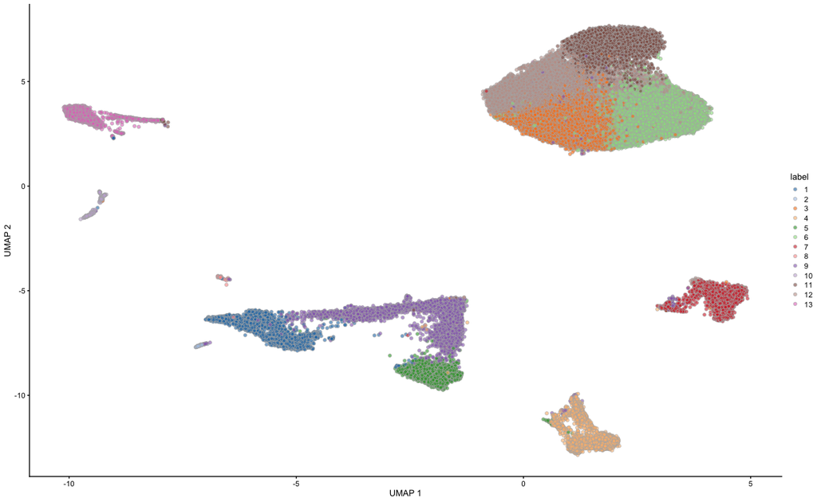

```r
is.mito <- grepl("^MT-", rownames(sce))
qcstats <- perCellQCMetrics(sce, subsets=list(Mito=is.mito))
filtered <- quickPerCellQC(qcstats, percent_subsets="subsets_Mito_percent")
sce <- sce[, !filtered$discard]

# Normalization.
sce <- logNormCounts(sce)

# Feature selection.
library(scran)
dec <- modelGeneVar(sce)
hvg <- getTopHVGs(dec, prop=0.1)

# Dimensionality reduction.
set.seed(1234)
sce <- runPCA(sce, ncomponents=25, subset_row=hvg)
sce <- runUMAP(sce, dimred = 'PCA', external_neighbors=TRUE)

# Clustering.
g <- buildSNNGraph(sce, use.dimred = 'PCA')
colLabels(sce) <- factor(igraph::cluster_louvain(g)$membership)

# Visualization.
plotUMAP(sce, colour_by="label")
```

# 3 Reducción de la dimensionalidad

## 3.1 PCA

```r
library(scRNAseq)
sce.zeisel <- ZeiselBrainData()
```

```
## snapshotDate(): 2020-04-27
```

```
## see ?scRNAseq and browseVignettes('scRNAseq') for documentation
```

```
## loading from cache
```

```
## see ?scRNAseq and browseVignettes('scRNAseq') for documentation
```

```
## loading from cache
```

```
## see ?scRNAseq and browseVignettes('scRNAseq') for documentation
```

```
## loading from cache
```

```
## snapshotDate(): 2020-04-27
```

```
## see ?scRNAseq and browseVignettes('scRNAseq') for documentation
```

```
## loading from cache
```

```r
library(scater)
sce.zeisel <- aggregateAcrossFeatures(sce.zeisel,
    id=sub("_loc[0-9]+$", "", rownames(sce.zeisel)))

#--- gene-annotation ---#
library(org.Mm.eg.db)
```

```r
rowData(sce.zeisel)$Ensembl <- mapIds(org.Mm.eg.db,
    keys=rownames(sce.zeisel), keytype="SYMBOL", column="ENSEMBL")
#--- quality-control ---#
stats <- perCellQCMetrics(sce.zeisel, subsets=list(
    Mt=rowData(sce.zeisel)$featureType=="mito"))
qc <- quickPerCellQC(stats, percent_subsets=c("altexps_ERCC_percent",
    "subsets_Mt_percent"))
sce.zeisel <- sce.zeisel[,!qc$discard]

#--- normalization ---#
library(scran)
set.seed(1000)
clusters <- quickCluster(sce.zeisel)
sce.zeisel <- computeSumFactors(sce.zeisel, cluster=clusters)
sce.zeisel <- logNormCounts(sce.zeisel)

#--- variance-modelling ---#
dec.zeisel <- modelGeneVarWithSpikes(sce.zeisel, "ERCC")
top.hvgs <- getTopHVGs(dec.zeisel, prop=0.1)
```

```r
BiocManager::install("PCAtools")
library(scran)
top.zeisel <- getTopHVGs(dec.zeisel, n=2000)

library(scater)
set.seed(100) # See below.
sce.zeisel <- runPCA(sce.zeisel, subset_row=top.zeisel)
reducedDimNames(sce.zeisel)
```

```
## [1] "PCA"
```

```r
library(BiocSingular)
set.seed(1000)
sce.zeisel <- runPCA(sce.zeisel, subset_row=top.zeisel,
    BSPARAM=RandomParam(), name="IRLBA")
reducedDimNames(sce.zeisel)
```

```
## [1] "PCA"   "IRLBA"
```

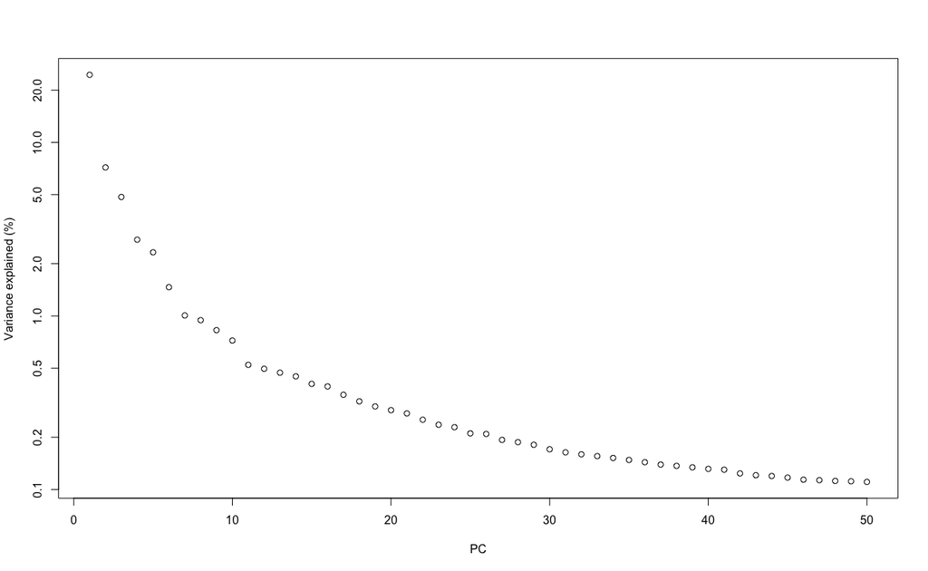

```r
percent.var <- attr(reducedDim(sce.zeisel), "percentVar")
plot(percent.var, log="y", xlab="PC", ylab="Variance explained (%)")
```

```r
percent.var <- attr(reducedDim(sce.zeisel), "percentVar")
chosen.elbow <- PCAtools::findElbowPoint(percent.var)
chosen.elbow
```

```
## [1] 7
```

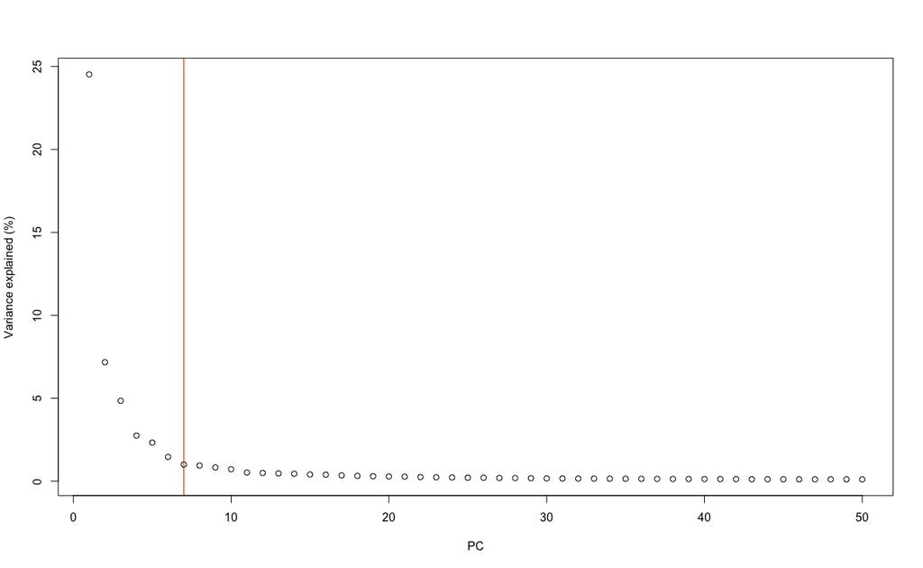

```r
plot(percent.var, xlab="PC", ylab="Variance explained (%)")
abline(v=chosen.elbow, col="red")
```

```r
# Creating a new entry with only the first 20 PCs,
# useful if we still need the full set of PCs later.
reducedDim(sce.zeisel, "PCA.elbow") <- reducedDim(sce.zeisel)[,1:chosen.elbow]
reducedDimNames(sce.zeisel)
```

```
## [1] "PCA"       "IRLBA"     "PCA.elbow"
```

```r
# Alternatively, just overwriting the original PCA entry. For demonstration
# purposes, we'll do this to a copy so that we still have full PCs later on.
sce.zeisel.copy <- sce.zeisel
reducedDim(sce.zeisel.copy) <- reducedDim(sce.zeisel.copy)[,1:chosen.elbow]
ncol(reducedDim(sce.zeisel.copy))
```

```
## [1] 7
```

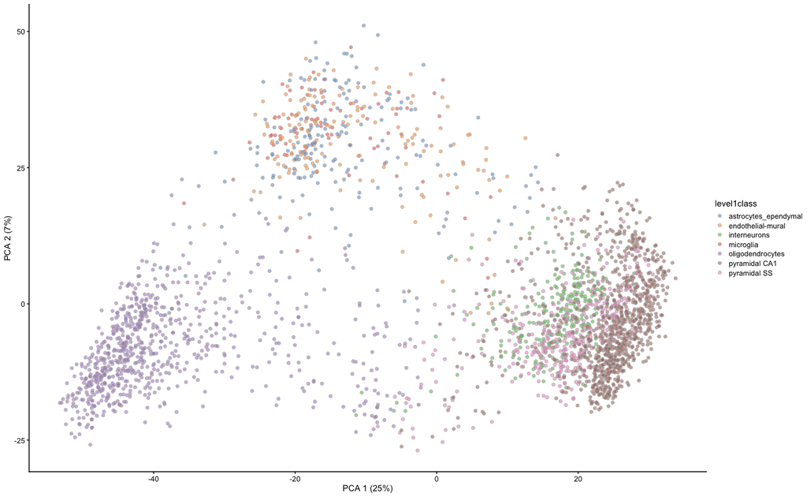

```r
plotReducedDim(sce.zeisel, dimred="PCA", colour_by="level1class")
```

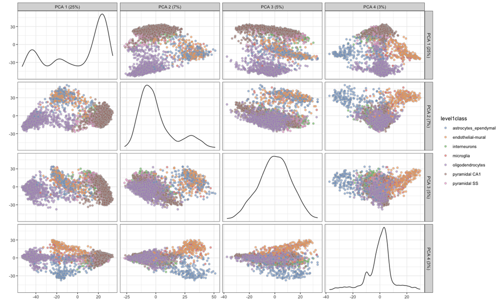

```r
plotReducedDim(sce.zeisel, dimred="PCA", ncomponents=4,
    colour_by="level1class")
```

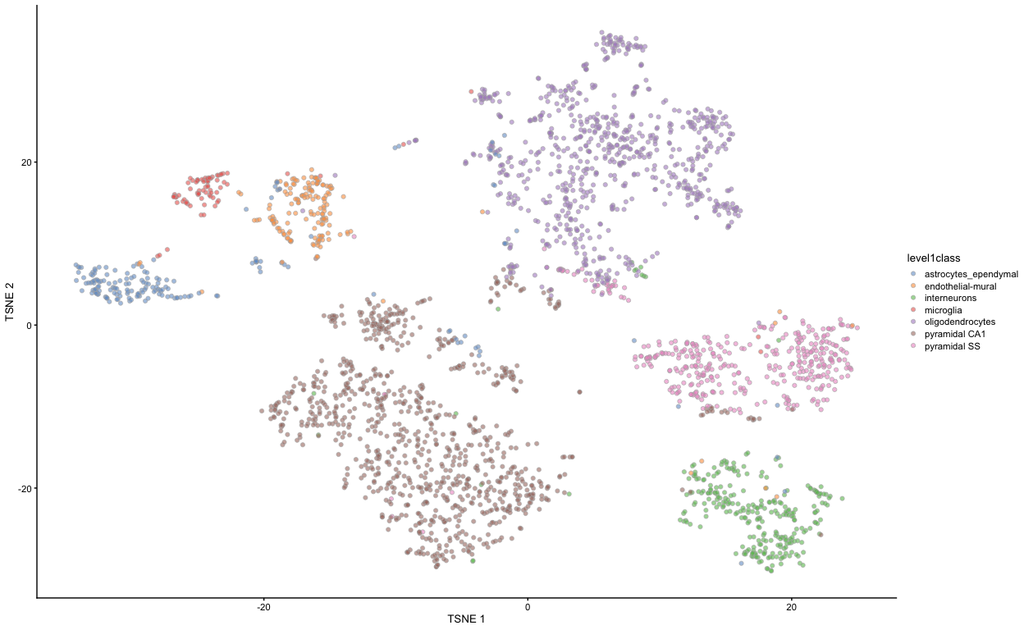

```r
set.seed(00101001101)

# runTSNE() stores the t-SNE coordinates in the reducedDims
# for re-use across multiple plotReducedDim() calls.
sce.zeisel <- runTSNE(sce.zeisel, dimred="PCA")
plotReducedDim(sce.zeisel, dimred="TSNE", colour_by="level1class")
```

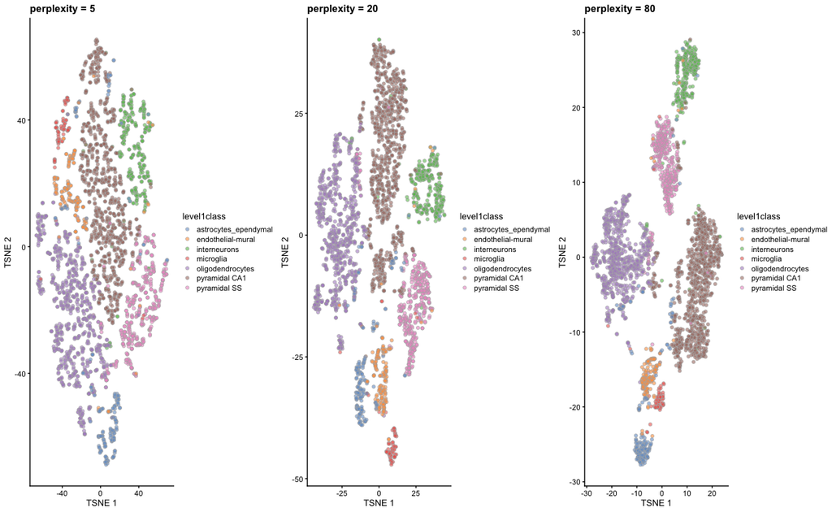

```r
set.seed(100)
sce.zeisel <- runTSNE(sce.zeisel, dimred="PCA", perplexity=5)
out5 <- plotReducedDim(sce.zeisel, dimred="TSNE",
    colour_by="level1class") + ggtitle("perplexity = 5")

set.seed(100)
sce.zeisel <- runTSNE(sce.zeisel, dimred="PCA", perplexity=20)
out20 <- plotReducedDim(sce.zeisel, dimred="TSNE",
    colour_by="level1class") + ggtitle("perplexity = 20")

set.seed(100)
sce.zeisel <- runTSNE(sce.zeisel, dimred="PCA", perplexity=80)
out80 <- plotReducedDim(sce.zeisel, dimred="TSNE",
    colour_by="level1class") + ggtitle("perplexity = 80")

gridExtra::grid.arrange(out5, out20, out80, ncol=3)
```

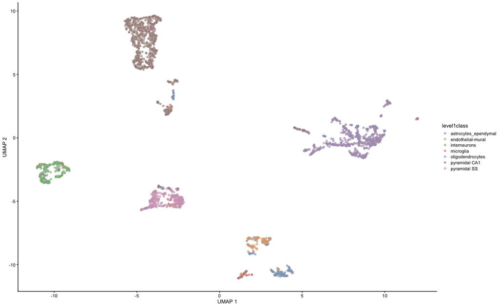

```r
set.seed(1100101001)
sce.zeisel <- runUMAP(sce.zeisel, dimred="PCA")
plotReducedDim(sce.zeisel, dimred="UMAP", colour_by="level1class")
```

# 4 Clusterización

Por si no las tienen instaladas

```r
#BiocManager::install("DropletTestFiles")
#BiocManager::install("DropletUtils")
#BiocManager::install("EnsDb.Hsapiens.v86")
```